# Practical_Machine_Learning_Assignment

Gianluca Kikidis

28/6/2021

## Practical Machine Learning Assignment

# Prediction models

The goal in this assignment project is to test different prediction models and see which one fits best in order to predict the manner in which people did certain exercises. This is the “classe” variable in the training set.

The training data for this project are available here:

https://d396qusza40orc.cloudfront.net/predmachlearn/pml-training.csv

The test data are available here:

https://d396qusza40orc.cloudfront.net/predmachlearn/pml-testing.csv

The data for this project come from this source: http://web.archive.org/web/20161224072740/http:/groupware.les.inf.puc-rio.br/har.

First, I load our packages needed:

```r
library(caret)
library(randomForest)
```

```r
library(rpart)
library(rpart.plot)
library(dplyr)
library(corrplot)
library(gbm)
library(rattle)
```

Then, I load the testing and training set (i load them locally because of computer related problems)

```r
training <- read.csv("pml-training.csv", stringsAsFactors = F,na.strings = c("","NA","#DIV/0!"))
testing <- read.csv("pml-testing.csv", stringsAsFactors = F,na.strings = c("","NA","#DIV/0!"))
dim(training);dim(testing)
```

```
## [1] 19622   160
```

```
## [1]  20 160
```

```r
inTrain <- createDataPartition(training$classe, p = 0.75, list = F)
training <- training[inTrain,]
testing <- training[-inTrain,]
dim(training); dim(testing)
```

```
## [1] 14718   160
```

```
## [1] 3678  160
```

## Data pre processing

I remove near zero variables that won’t be needed for further analysis:

```r
zero <- nearZeroVar(training)
training <- training[, -zero]
testing  <- testing[, -zero]
```

I also remove variables that are over 95% NA

```r
na    <- sapply(training, function(x) mean(is.na(x))) > 0.95
training <- training[, na==FALSE]
testing  <- testing[, na==FALSE]
```

And finally i remove identification correlated variables that i do not need:

```r
training <- training[, -(1:5)]
testing  <- testing[, -(1:5)]
dim(training); dim(testing)
```

```
## [1] 14718    54
```

```
## [1] 3678   54
```

## Prediction models

Now, with the Pre process done i start the first prediction model (my favorite), which is random forest:

```r
set.seed(1234)
control <- trainControl(method="cv", number=3, verboseIter=FALSE)
RandomForest <- train(classe ~ ., data=training, method="rf",
                          trControl=control)
RandomForest$finalModel
```

```
##
## Call:
##  randomForest(x = x, y = y, mtry = min(param$mtry, ncol(x)))
##                Type of random forest: classification
##                      Number of trees: 500
## No. of variables tried at each split: 27
##
##         OOB estimate of  error rate: 0.2%
## Confusion matrix:
##      A    B    C    D    E  class.error
## A 4184    0    0    0    1 0.0002389486
## B    8 2838    2    0    0 0.0035112360
## C    0    7 2560    0    0 0.0027269186
## D    0    0    7 2404    1 0.0033167496
## E    0    1    0    2 2703 0.0011086475
```

I create a confusion matrix for the model and make a prediction:

```r
testing$classe <- as.factor(testing$classe)
RForestPrediction <- predict(RandomForest, testing)
RForestconfmat <- confusionMatrix(RForestPrediction, testing$classe)
RForestconfmat
```

```
## Confusion Matrix and Statistics
##
##           Reference
## Prediction    A    B    C    D    E
##          A 1020    0    0    0    0
##          B    0  753    0    0    0
##          C    0    0  632    0    0
##          D    0    0    0  598    0
##          E    0    0    0    0  675
##
## Overall Statistics
##
##                Accuracy : 1
##                  95% CI : (0.999, 1)
##     No Information Rate : 0.2773
##     P-Value [Acc > NIR] : < 2.2e-16
##
##                   Kappa : 1
##
##  Mcnemar's Test P-Value : NA
##
## Statistics by Class:
##
##                      Class: A Class: B Class: C Class: D Class: E
## Sensitivity            1.0000   1.0000   1.0000   1.0000   1.0000
## Specificity            1.0000   1.0000   1.0000   1.0000   1.0000
## Pos Pred Value         1.0000   1.0000   1.0000   1.0000   1.0000
## Neg Pred Value         1.0000   1.0000   1.0000   1.0000   1.0000
## Prevalence             0.2773   0.2047   0.1718   0.1626   0.1835
## Detection Rate         0.2773   0.2047   0.1718   0.1626   0.1835
## Detection Prevalence   0.2773   0.2047   0.1718   0.1626   0.1835
## Balanced Accuracy      1.0000   1.0000   1.0000   1.0000   1.0000
```

Here is the plot also:

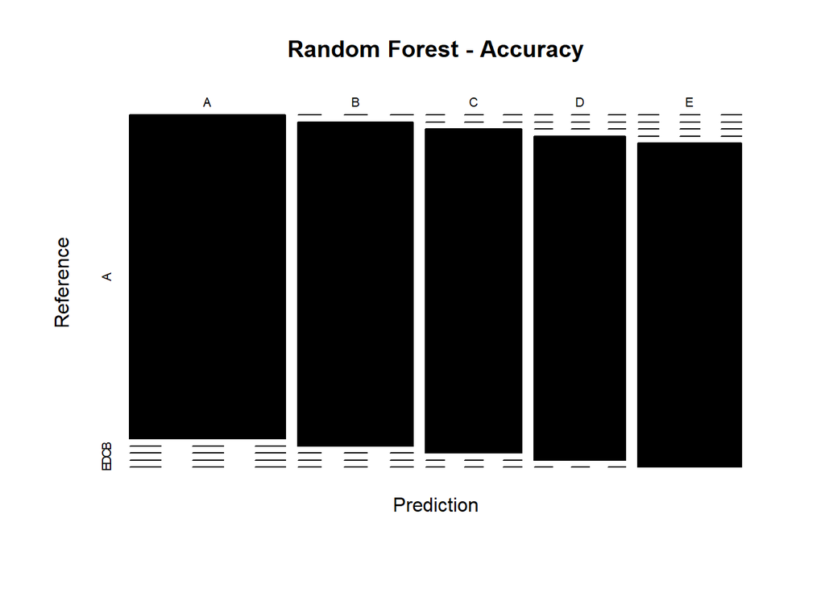

```r
plot(RForestconfmat$table, col = RForestconfmat$byClass,
           main = paste("Random Forest - Accuracy"))
```

```r
RForestconfmat$overall['Accuracy']
```

```
## Accuracy
##        1
```

And the accuracy, which is: 100%

## Generalized Boosted Model

I tried generalized boosted models, but sadly my pc could not handle it. I tried it on another PC too, but it might be to heavy and ram eating… therefore i just post the code i would have used for this model:

```r
# set.seed(1234)
# gbm<- train(classe~., data=training, method="gbm", verbose= FALSE)
# gbm$finalmodel

# gbm$overall
# plot(gbm$table, col = gbm$byClass,
#     main = paste("GBM - Accuracy =", round(gbm$overall['Accuracy'], 4)))
```

## Decision tree

Next step is the decision tree model:

```r
DecTree<- train(classe ~. , data=training, method= "rpart")
```

Here is the plot:

[figure not shown]

```r
fancyRpartPlot(DecTree$finalModel)
```

And the results:

```r
DecTree$results
```

```
##           cp  Accuracy      Kappa AccuracySD   KappaSD
## 1 0.02772240 0.6202474 0.51730951 0.03069169 0.0376324
## 2 0.04364062 0.4752490 0.30264849 0.07925871 0.1272002
## 3 0.11525681 0.3372459 0.07953428 0.03902905 0.0609573
```

Next, i once again make the prediction and create a confusion matrix:

```r
set.seed(1234)
DecTree_pred<- predict(DecTree, testing)
confusionMatrix(DecTree_pred, testing$classe)
```

```
## Confusion Matrix and Statistics
##
##           Reference
## Prediction   A   B   C   D   E
##          A 899 144  64 142  48
##          B  46 405  59 134 121
##          C  74 204 509 291 106
##          D   0   0   0   0   0
##          E   1   0   0  31 400
##
## Overall Statistics
##
##                Accuracy : 0.6017
##                  95% CI : (0.5857, 0.6176)
##     No Information Rate : 0.2773
##     P-Value [Acc > NIR] : < 2.2e-16
##
##                   Kappa : 0.4911
##
##  Mcnemar's Test P-Value : < 2.2e-16
##
## Statistics by Class:
##
##                      Class: A Class: B Class: C Class: D Class: E
## Sensitivity            0.8814   0.5378   0.8054   0.0000   0.5926
## Specificity            0.8503   0.8769   0.7784   1.0000   0.9893
## Pos Pred Value         0.6931   0.5294   0.4299      NaN   0.9259
## Neg Pred Value         0.9492   0.8805   0.9507   0.8374   0.9153
## Prevalence             0.2773   0.2047   0.1718   0.1626   0.1835
## Detection Rate         0.2444   0.1101   0.1384   0.0000   0.1088
## Detection Prevalence   0.3526   0.2080   0.3219   0.0000   0.1175
## Balanced Accuracy      0.8658   0.7074   0.7919   0.5000   0.7910
```

## Conclusion

In conclusion, Random Forest has a higher accuracy compared to Decision Trees, and my guess would be: slightly higher than GBM also, with a 100% accuracy.

## Final Prediction

This is hence the final prediction with Random Forest:

```r
Prediction = predict(RandomForest, testing)
head(Prediction)
```

```
## [1] A A A A A A
## Levels: A B C D E
```